# Principle Component Analysis II

## Principle Component Analysis (PCA)

Produces a low-dimensional representation of a dataset. It finds a sequence of linear combinations of the variables that have maximal variance and are mutually uncorrelated.

Used to:

- Visualize structure in data
- Learn about latent meta-variables
- Produce imputs for subsequent supervised learning

## Handwritten Letters

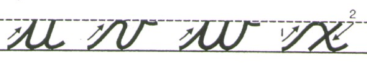

How much information is encoded in a 8 x 8 image of a handwritten letters?

## Practice

Find the code to download the handwritten data set on the website under Week 10.

1. What do the columns and rows appear to represent in this dataset?
2. Select a letter of the alphabet and create a new dataset that includes only the images of that letter.
3. Visualize a few of those images using `plot_letter()` function.
4. Compute the *mean* image for that letter and visualize it.

## Plot letter

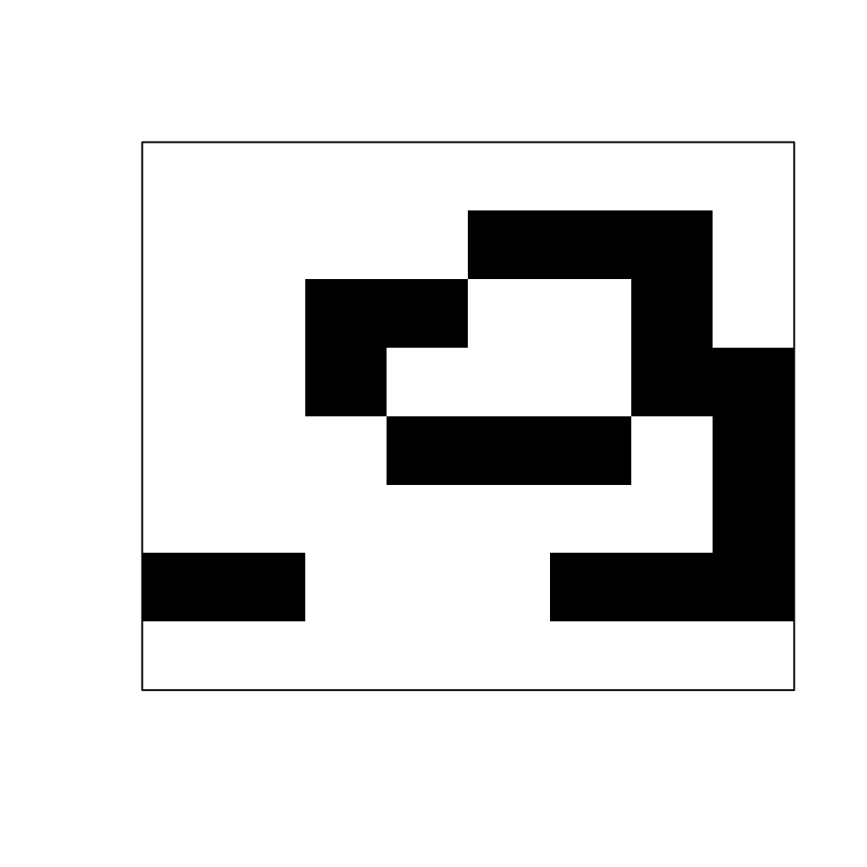

## Mean letter

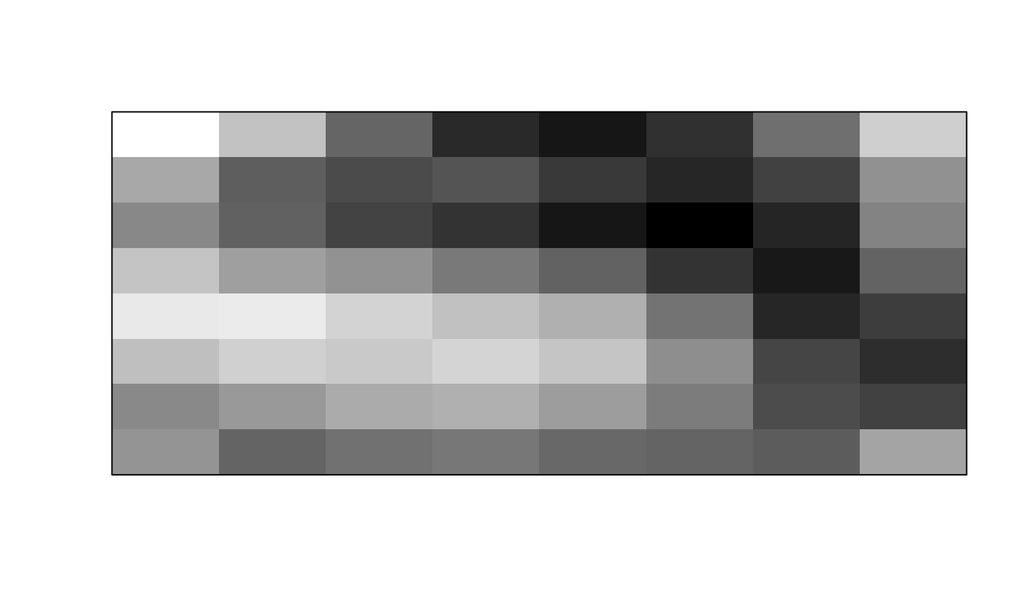

```r
g_mean <- colSums(g_data[, -1])/nrow(g_data)
plot_letter(g_mean, hasletter = FALSE)
```

## Dimension reduction

Can we capture most of the structure in a smaller number of dimensions?

\[m < p ?\]

1. Perform PCA on your data set using the `prcomp()` function (detailed in the slides from last time).
2. Construct a scree plot showing the PVE for the first 20 PCs.

## Plotting the PCs

```r
pca1 <- prcomp(g_data[, -1])
d <- as.data.frame(pca1$x)
library(ggplot2)
p1 <- ggplot(d, aes(x = PC1, y = PC2)) +
  geom_point(alpha = .4)
```

## Plotting the PCs

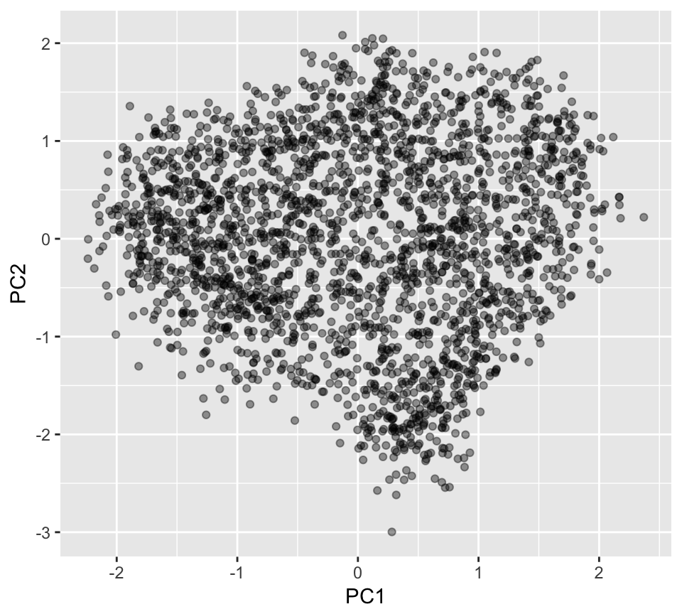

## Scree plot

Used to visualize the proportion of variance explained (PVE) by each PC.

## Scree plot

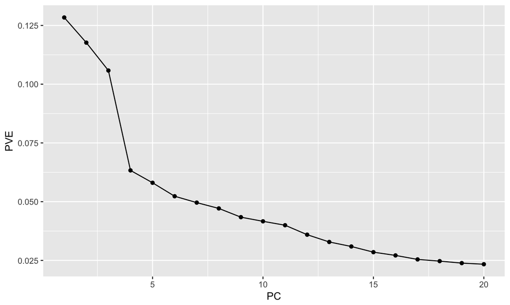

## Scree plot

A good amount of the structure in the data resides in the first 4 PCs (PVE: 0.4151918)

But what do these PCs actually mean?

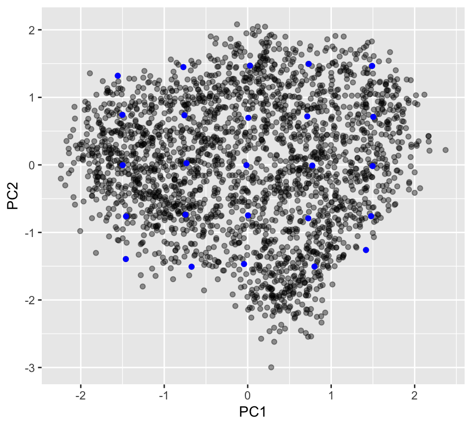

## What do the PCs mean?

Difficult to tell due to

- Low resolution
- Lots of information to synthesize

But there is another way to learn about these first two PCs…

## Practice

1. Extract the loadings (`rotation`) from your PCA object and used `plot_letter()` to plot your first several PCs. What variation they seem to be capturing?
2. Generate a 5x5 plot of the images of letters sampled from a regular grid across the first two PCs (use `pc_grid()` in the updated code file from last class.) Do these conform with the direct images of the loadings?

First, reset graphical parameters.

```r
dev.off()
```

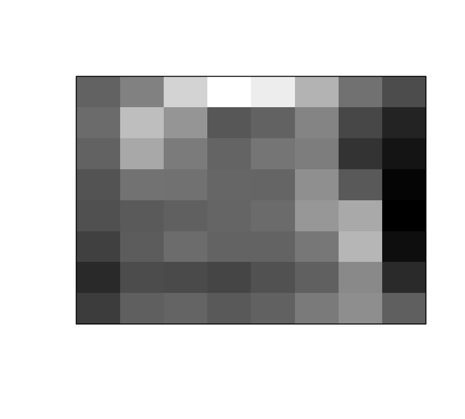

```r
plot_letter(pca1$rotation[, 1], hasletter = FALSE)
```

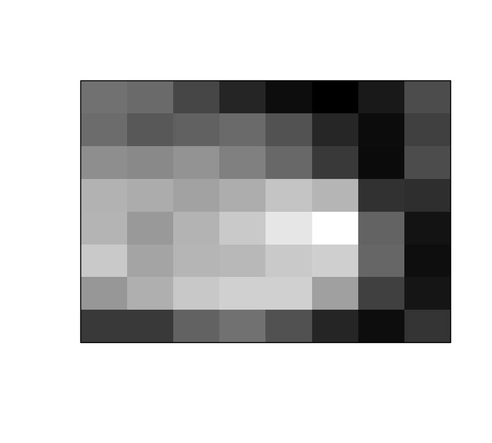

```r
plot_letter(pca1$rotation[, 2], hasletter = FALSE)
```

```r
pc_grid(pca1, g_data)
```

[output not shown]

## Image reconstruction

Use the first two principle components to reconstruct (and visualize) the first two letters in your data set. For each letter, plot the true image and the reconstructed image on the sampe plot. How much information was lost?

```r
phi <- pca1$rotation
z <- pca1$x
x_star1 <- g_mean + phi[, 1] * z[1, 1] + phi[, 2] * z[1, 2]
x_star2 <- g_mean + phi[, 1] * z[2, 1] + phi[, 2] * z[2, 2]
```

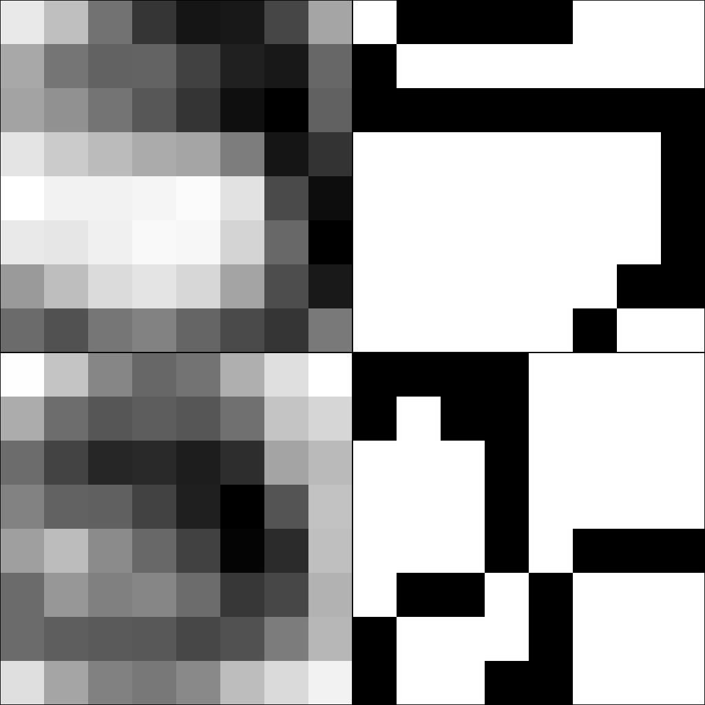

```r
par(mfrow = c(2, 2), mar = rep(0, 4))
plot_letter(x_star1, hasletter = FALSE)
plot_letter(g_data[1,], hasletter = TRUE)
plot_letter(x_star2, hasletter = FALSE)
plot_letter(g_data[2,], hasletter = TRUE)
```